# Python-R-Xenium.Rmd

*Nabila Rahman*

*2025-08-19*

```python
import squidpy as sq   # The spatial analysis engine: cell-cell interactions, co-occurrence, network analysis
import scanpy as sc    # Data Structure: Single-cell data handling (AnnData objects, basic preprocessing)
import pandas as pd    # Data wrangling: handling coordinate tables, metadata, results
import numpy as np     # Math operations: array handling, mathematical calculations

#~~~~~~~~~~~~~~~~~~~~~~~
# Configure scanpy
#~~~~~~~~~~~~~~~~~~~~~~
# sc.settings.verbosity = 0  # Only errors (silent)
# sc.settings.verbosity = 1  # Errors + warnings
# sc.settings.verbosity = 2  # + important info
# sc.settings.verbosity = 3  # + detailed progress (DEFAULT in our script)
# sc.settings.verbosity = 4  # + debug info (very chatty)
sc.settings.verbosity = 3
```

*From Nils’ Tutorial*

- analysis.tar.gz / analysis.zarr.zip : secondary analysis results which can be explored with the XeniumExplorer software
- analysis_summary.html : Html report of the sample run, containing summary metrics and automated secondary analysis results
- aux_outputs.tar.gz : auxillary outputs with raw data before decoding (downsampled, no reprocessing possible from these files)
- cells.parquet / cells.csv.gz / cells.zarr.zip : cell metadata including cell spatial location saved in different file formats
- cell_feature_matrix.zarr.zip / cell_feature_matrix.h5 / cell_feature_matrix.tar.gz : cells x genes count matrices in different file formats
- cell_boundaries.parquet / cell_boundaries.csv.gz:
- experiment.xenium : experiment manifest file in JSON format that includes experiment metadata
- gene_panel.json : a copy of the gene panel file used in the experiment on the Xenium Analyzer instrument, the JSON schema contains gene name, ENSEMBL ID and gene coverage
- morphology.ome.tif : DAPI image of the sample
- nucleaus_boundaries.parquet / nucleus_boundaries.csv.gz :representation of the nucleus boundaries, each row represents a vertex in the boundary polygon of one nucleus
- transcripts.csv.gz / transcripts.parquet / transcripts.zarr.zip : the file contains one row for each decoded transcript with spatial coordinates, quality metrics and distance to nucleus

More information: https://www.10xgenomics.com/support/software/xenium-onboard-analysis/latest/analysis/xoa-output-understanding-outputs

*Note:* Legacy dataset’ doesn’t have’s cells.csv.gz doesn’t say how the cells were segmented. Normally this column shows: “cell_boundary”, “nuclear_expansion”, “multimodal”, etc. You can’t filter cells by segmentation method (not usually needed)

```r
# Use Seurat v5 for efficient loading and BUILT-IN spatial analysis and sketch immediately (Seurat v5 approach)
xenium_obj <- LoadXenium("G:/SpatialOmics/Xenium/Raw/outs") %>%
  SketchData(ncells = 50000)  # Sample first, then QC the sketch

# Seurat automatically:
# Filters on decoding quality (qv >= 20)
# Keeps only real transcripts (is_gene = True)
# Excludes decoy/control barcodes
# Assigns transcripts to cells based on cell boundaries
```

### 0.1 Expected in this dataset

| **Platform** | 10x Genomics’ subcellular Xenium In Situ platform |
| --- | --- |
| **Dataset** | Human Breast Cancer (from 10x Genomics bioRxiv pre-print |
| **Note:** | Legacy Dataset - QC probe names and image alignment changed since release. |

From the loaded dataset there are: 541 total features (genes + quality controls) split across 4 data types [ This will be 854 total features across 5 dataset if you use sketch. since an extra assay added. ]

313 actual genes measured

Quality control assays from Xenium: - **BlankCodeword:** Measures background/noise levels - **ControlCodeword**: Technical controls for data quality - **ControlProbe**: Positive controls to verify the assay worked

1 spatial slice This is the spatial coordinates and imaging data Contains cell positions, boundaries, and tissue image

```r
xenium_obj
```

```
## An object of class Seurat
## 854 features across 167780 samples within 5 assays
## Active assay: sketch (313 features, 0 variable features)
##  1 layer present: counts
##  4 other assays present: Xenium, BlankCodeword, ControlCodeword, ControlProbe
##  1 spatial field of view present: fov
```

## 1 QC

**Red Flags vs. Normal Variation:**

- **Concerning ranges:** - >20% outliers - suggests technical problems - Very low transcript counts (<5) - poor assay performance - Extreme high counts (>5,000) - major doublet issues - Many 0-gene cells (>15%) - poor segmentation
- **Normal Biological Variation:** - 5-15% outliers - expected biological diversity - Some high-activity cells - metabolically active regions - Some low-activity cells - quiescent cell types - Few 0-gene cells (<5%) - normal segmentation errors

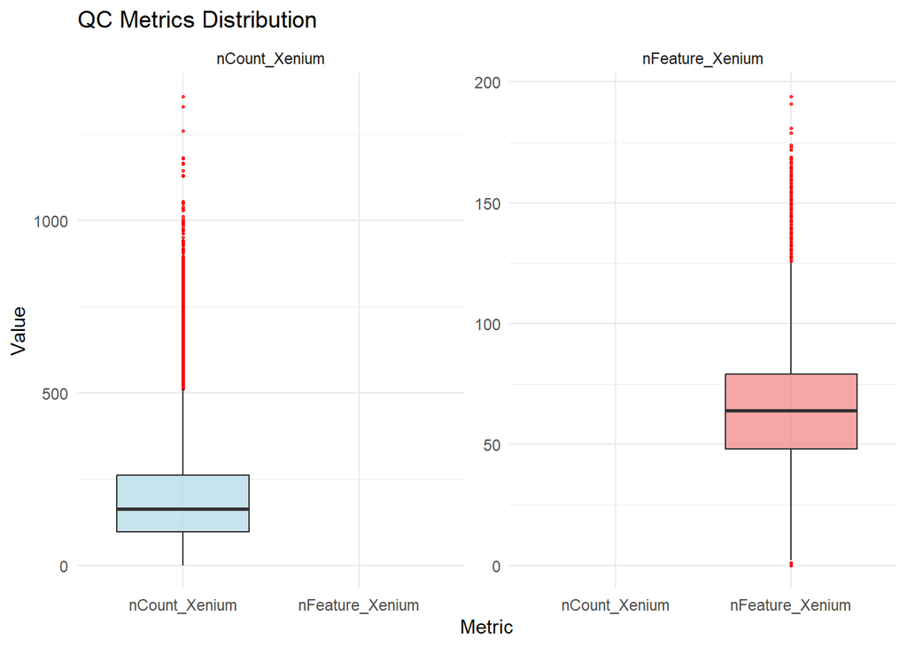

```r
# Reshape data for combined plotting
plot_data <- xenium_obj@meta.data %>%
  select(nCount_Xenium, nFeature_Xenium) %>%
  gather(key = "metric", value = "value")

# Find cells with extreme values
ncount_outliers <- boxplot.stats(xenium_obj$nCount_Xenium)$out
nfeature_outliers <- boxplot.stats(xenium_obj$nFeature_Xenium)$out

# Calculate statistics
total_cells <- ncol(xenium_obj)
zero_genes <- sum(xenium_obj$nFeature_Xenium == 0)

# Create combined boxplot
ggplot(plot_data, aes(x = metric, y = value, fill = metric)) +
  geom_boxplot(alpha = 0.7, outlier.colour = "red", outlier.size = 0.5) +
  scale_fill_manual(values = c("lightblue", "lightcoral")) +
  labs(title = "QC Metrics Distribution",
       x = "Metric", y = "Value") +
  theme_minimal() +
  theme(legend.position = "none") +
  facet_wrap(~metric, scales = "free_y")
```

```r
# Create summary table
outlier_summary <- data.frame(
  QC_Metric = c(
    "Transcript Count Outliers"
    , "Gene Count Outliers"
    , "Zero-Gene Cells"
  )
  , Count = c(
    length(ncount_outliers)
    , length(nfeature_outliers)
    , zero_genes
  )
  , Percentage = paste0(
    c(
      round(length(ncount_outliers)/total_cells*100, 1)
      , round(length(nfeature_outliers)/total_cells*100, 1)
      , round(zero_genes/total_cells*100, 1)
    ), "%"
  )
  , Range = c(
    paste(min(ncount_outliers), "to", max(ncount_outliers))
    , paste(min(nfeature_outliers), "to", max(nfeature_outliers))
    , "0 genes"
  )
)

# Display table
kable(
  outlier_summary
  , caption = "Xenium Data Quality Summary - Within Range"
  , col.names = c("QC Metric", "Count", "Percentage", "Range")
)
```

Table 1: Xenium Data Quality Summary - Within Range

| QC Metric | Count | Percentage | Range |
| --- | --- | --- | --- |
| Transcript Count Outliers | 3960 | 2.4% | 512 to 1359 |
| Gene Count Outliers | 3406 | 2% | 0 to 194 |
| Zero-Gene Cells | 1417 | 0.8% | 0 genes |

## 2 Filtering

```r
#~~~~~~~~~~~~~~~~~~~~~~~~~~~~~~~~~~~~~~~~~~~~~~~~~~~#
# Check that gene features do not contain any decoy barcodes
#~~~~~~~~~~~~~~~~~~~~~~~~~~~~~~~~~~~~~~~~~~~~~~~~~~~#
gene_names <- rownames(xenium_obj@assays$sketch)

# Check for legitimate gene symbols
valid_gene_symbols <- all(grepl("^[A-Z][A-Z0-9-]*$", gene_names))

# Check for legitimate ensembl ID
#valid_gene_symbols <- all(grepl("^ENSG", gene_names))


cat("All genes follow gene symbol pattern:", valid_gene_symbols, "\n")
```

```
## All genes follow gene symbol pattern: FALSE
```

```r
# Show some examples
cat("First 10 gene symbols:", paste(head(gene_names, 10), collapse = ", "), "\n")
```

```
## First 10 gene symbols: ABCC11, ACTA2, ACTG2, ADAM9, ADGRE5, ADH1B, ADIPOQ, AGR3, AHSP, AIF1
```

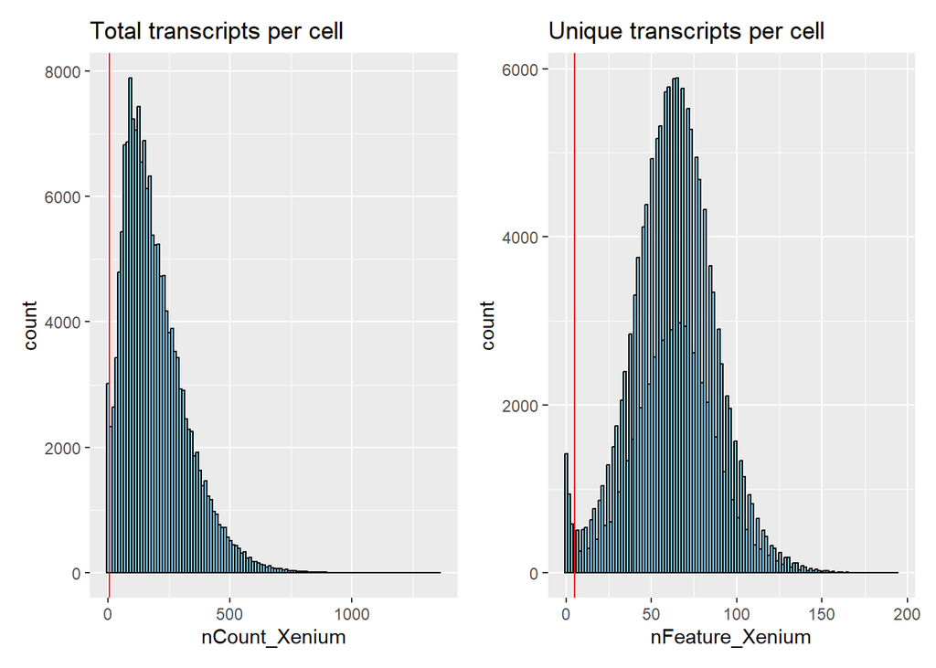

```r
#~~~~~~~~~~~~~~~~~~~~~~~~~~~~~~~~~~~~~~~#
# Add % counts in top n genes
#~~~~~~~~~~~~~~~~~~~~~~~~~~~~~~~~~~~~~~~#
# Calculate top gene percentages (Seurat equivalent)
calculate_top_gene_percent <- function(seurat_obj, top_n = c(10, 20, 50, 150), assay="sketch") {

  # Get expression matrix
  expr_matrix <- GetAssayData(seurat_obj, assay = assay, slot = "counts")

  for(n in top_n) {
    # For each cell, find top N genes and calculate percentage
    top_pct <- apply(expr_matrix, 2, function(cell) {
      top_genes <- head(sort(cell, decreasing = TRUE), n)
      sum(top_genes) / sum(cell) * 100
    })

    # Add to metadata
    seurat_obj[[paste0("pct_counts_in_top_", n, "_genes")]] <- top_pct
  }

  return(seurat_obj)
}

# Apply to your data
xenium_obj <- calculate_top_gene_percent(xenium_obj)

# Total transcripts per cell - Count
p1 <- ggplot(xenium_obj@meta.data, aes(x = nCount_Xenium, )) +
  geom_histogram(bins = 120, color="black", fill="skyblue") + labs(title = "Total transcripts per cell") +
  geom_vline(xintercept=5, color="red")

# Unique transcripts per cell - Features
p2 <- ggplot(xenium_obj@meta.data, aes(x = nFeature_Xenium)) +
  geom_histogram(bins = 120, color="black", fill="skyblue") + labs(title = "Unique transcripts per cell") +
  geom_vline(xintercept=5, color="red")


p1 | p2
```

```r
# Gentle filtering - only remove obvious junk
xenium_obj <- subset(xenium_obj
                     , subset = nFeature_Xenium > 5 &     # Remove cells with less than 5 gene cells
                                          nCount_Xenium > 5  # Remove cells with less than 5 transcripts
                     )
```

### 2.1 Basic processing (Seurat)

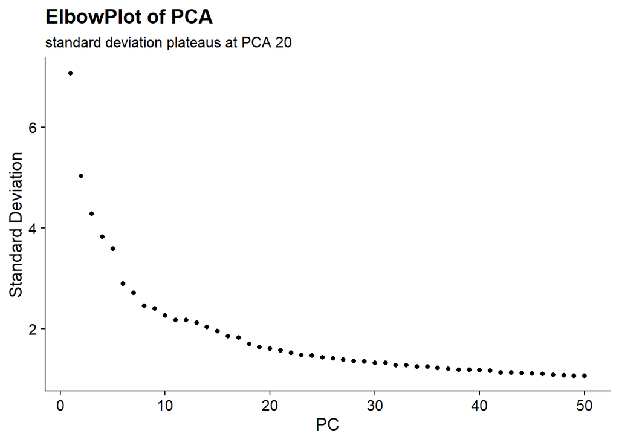

```r
xenium_obj <- SCTransform(xenium_obj, assay = 'sketch' )
xenium_obj <- RunPCA(xenium_obj)

# Determine optimal number of PCs
ElbowPlot(
  xenium_obj
  , ndims = 50
) +
  ggtitle("ElbowPlot of PCA", subtitle = "standard deviation plateaus at PCA 20"  )
```

```r
# Find neighbors and clusters
xenium_obj <- FindNeighbors(
  xenium_obj
  , dims = 1:20
  , verbose = FALSE
)

xenium_obj <- RunUMAP(
  xenium_obj
  , reduction = "pca"
  , dims = 1:30
)

xenium_obj <- FindClusters(xenium_obj
                           # , assay = 'sketch'  # arg  not needed
                           , resolution = 0.5
                           , verbose = FALSE
                           )
```

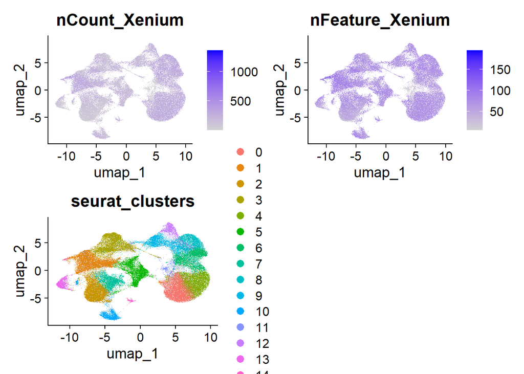

```r
p1 <- FeaturePlot(xenium_obj, features = "nCount_Xenium")
p2 <- FeaturePlot(xenium_obj, features = "nFeature_Xenium")
p3 <- DimPlot(xenium_obj, group.by = "seurat_clusters")

(p1 | p2) / ( p3 | plot_spacer())
```

Note: If the clusters do not appear clearly separated, this is due to errors in transcript to cell assignment due to imperfect segmentation. So you have to explore the effect of restricting transcript assignment based on distance to the segmented nucleus boundary. Unlike in python, Seurat already takes care of filters on decoding quality by setting “qv >= 20”. Keeps only real transcripts (is_gene = True) & excludes decoy/control barcodes. Seurat also assigns transcripts to cells based on cell boundaries.

```r
# First, check if Xenium output includes nucleus distance
transcripts_file <- "G:/SpatialOmics/Xenium/Raw/outs/transcripts.csv.gz"

# Quick peek at transcript columns
library(data.table)
transcripts_sample <- fread(transcripts_file)
colnames(transcripts_sample)
```

```
## [1] "transcript_id"    "cell_id"          "overlaps_nucleus" "feature_name"
## [5] "x_location"       "y_location"       "z_location"       "qv"
```

```r
# Look for nucleus_distance column
"nucleus_distance" %in% colnames(transcripts_sample)
```

```
## [1] FALSE
```

```r
# Filter transcripts based on nuclear distance ----#
if("nucleus_distance" %in% colnames(transcripts_sample)) {
  # Filter on nucleus distance
  # 0, 2 and 5 (μm) can also be thresholds to explore  (0  =   very strict,  5 is very permissive)
  transcripts_sample <- transcripts_sample[nucleus_distance <= 0.5]
} else {
  cat("No nucleus distance column - Seurat's default is fine\n")
}
```

```
## No nucleus distance column - Seurat's default is fine
```

No nucleus_distance column found in this dataset.

## 3 Spatial View of Clusters

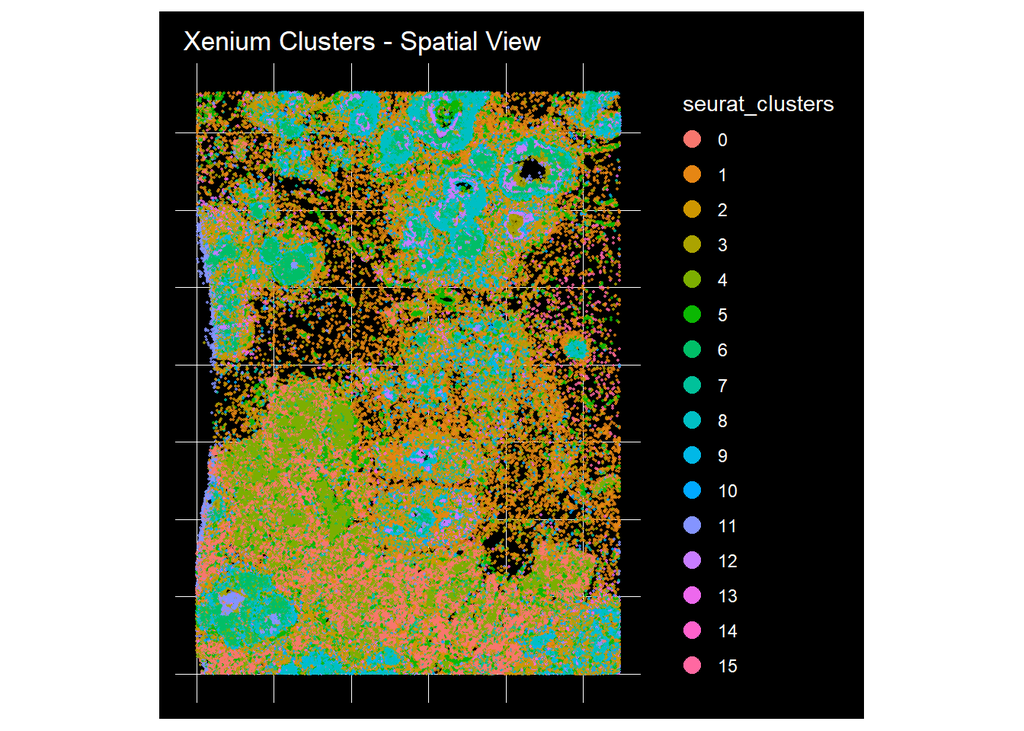

```r
# Instead of SpatialDimPlot(), use:
spatial_plot <- ImageDimPlot(
  xenium_obj
  , fov = names(xenium_obj@images)[1]  # Use available FOV
  , group.by = "seurat_clusters"
  , size = 0.7
  , alpha = 0.8
  , border.color = "NA"
) +
  labs(title = "Xenium Clusters - Spatial View") +
  NoAxes()

spatial_plot
```

## 4 Find Cluster Markers

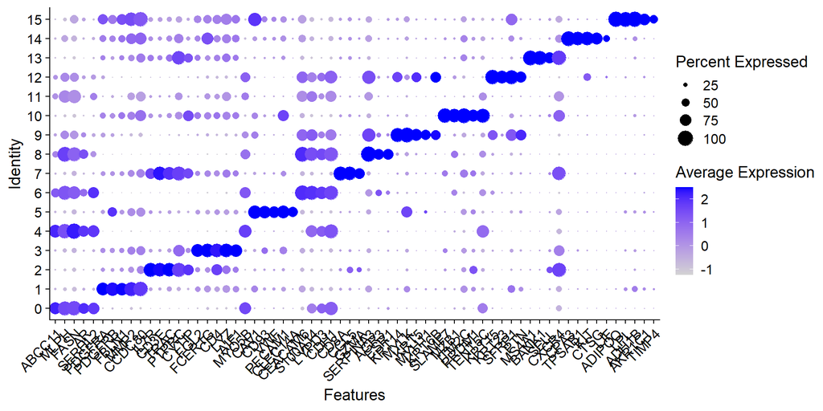

```r
# Find markers for all clusters at once
cluster_markers <- FindAllMarkers(
  xenium_obj
  ,  only.pos = TRUE          # Only positive markers (like scanpy default)
  , min.pct = 0.25          # Gene must be expressed in at least 25% of cells
  , logfc.threshold = 0.25   # Minimum log fold change
  , test.use = "wilcox"     # Wilcoxon test (scanpy default)
  ,  verbose = TRUE
)

top5 <- cluster_markers %>%
    group_by(cluster) %>%
    dplyr::filter(avg_log2FC > 1 & p_val_adj < 0.001) %>%
    slice_head(n = 5) %>%
    ungroup()

DotPlot(xenium_obj
        , features = unique(top5$gene)
        ,  group.by = "seurat_clusters") +
  RotatedAxis()
```

## 5 KDTree nearest neighbor search

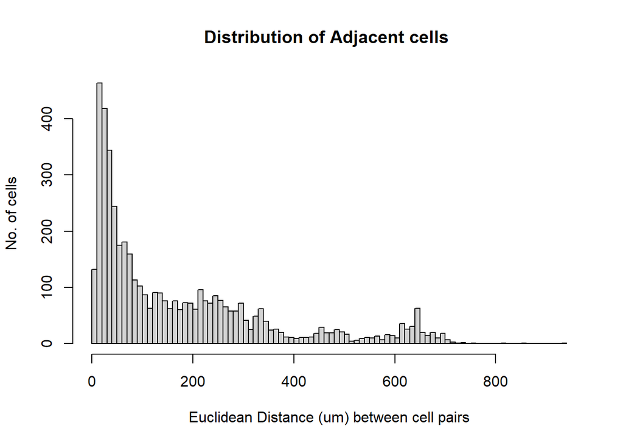

```r
# First, extract spatial coordinates for different leiden clusters

# Get spatial coordinates for all cells
spatial_coords <- GetTissueCoordinates(xenium_obj, image = "fov")


# Filter coordinates by leiden clusters
leiden1_coords <- spatial_coords[xenium_obj$seurat_clusters == "1", ]
leiden11_coords <- spatial_coords[xenium_obj$seurat_clusters == "11", ]

#  Run KDTree NN search
nn_result <- RANN::nn2(
  data = leiden1_coords,      # Reference points (tree data)
  query = leiden11_coords,    # Query points
  k = 1                       # Number of nearest neighbors
)

# Extract results
distances <- nn_result$nn.dists[, 1]  # Distances to nearest neighbor
indices <- nn_result$nn.idx[, 1]      # Indices of nearest neighbors

# Create results dataframe
nearest_neighbor_results <- data.frame(
  query_cell = rownames(leiden11_coords),
  nearest_leiden1_cell = rownames(leiden1_coords)[indices],
  distance = distances
)

# Visualise distances
hist(nearest_neighbor_results$distance, breaks=100, main="Distribution of Adjacent cells ", xlab="Euclidean Distance (um) between cell pairs", ylab="No. of cells")
```

## 6 Check distances for all clusters

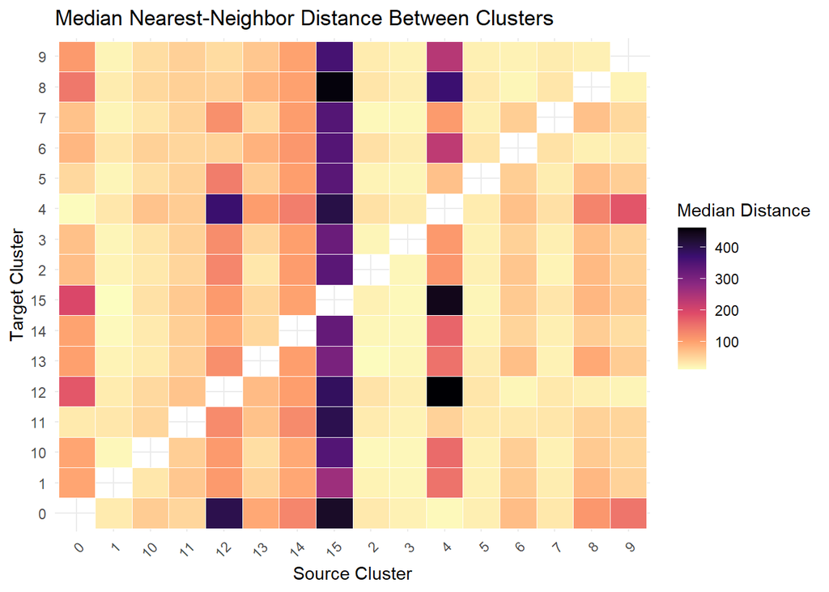

```r
# 1. Extract spatial coordinates
coords <- GetTissueCoordinates(xenium_obj)

# 2. Get cluster assignments
clusters <- Idents(xenium_obj)  # Or xenium_seg$leiden if stored in metadata
coords$cluster <- as.character(clusters[rownames(coords)])

# Get all unique pairs (excluding self)
cluster_levels <- sort(unique(coords$cluster))
cluster_pairs <- expand.grid(source = cluster_levels, target = cluster_levels) %>%
  filter(source != target)

# Compute median nearest-neighbor distances for each cluster pair
distance_summary <- lapply(seq_len(nrow(cluster_pairs)), function(i) {
  source_cluster <- cluster_pairs$source[i]
  target_cluster <- cluster_pairs$target[i]

  source_coords <- coords %>% filter(cluster == source_cluster) %>% select(x, y)
  target_coords <- coords %>% filter(cluster == target_cluster) %>% select(x, y)

  if (nrow(source_coords) == 0 || nrow(target_coords) == 0) return(NULL)

  nn <- nn2(data = source_coords, query = target_coords, k = 1)
  median_distance <- median(nn$nn.dists[, 1])

  data.frame(
    target = target_cluster,
    source = source_cluster,
    median_distance = median_distance
  )
})

# Combine
distance_matrix_df <- do.call(rbind, distance_summary)

# Optional: convert to wide format for matrix-like heatmap (e.g., pheatmap)
# But for ggplot2, keep it tidy

# Plot heatmap
ggplot(distance_matrix_df, aes(x = source, y = target, fill = median_distance)) +
  geom_tile(color = "white") +
  scale_fill_viridis_c(option = "magma", direction = -1) +
  labs(title = "Median Nearest-Neighbor Distance Between Clusters",
       x = "Source Cluster", y = "Target Cluster", fill = "Median Distance") +
  theme_minimal() +
  theme(axis.text.x = element_text(angle = 45, hjust = 1))
```

```r
library(Seurat)
library(Matrix)
library(dplyr)

# Pseudobulk function
pseudobulk_clusters <- function(xenium_obj, group.by = NULL, assay = "RNA", slot = "counts") {
  # If no grouping provided, use Idents
  if (is.null(group.by)) {
    group.by <- "ident"
    xenium_obj$ident <- Idents(xenium_obj)
  }

  # Extract raw count matrix
  counts <- GetAssayData(xenium_obj, assay = assay, slot = slot)

  # Get group assignments
  group_ids <- xenium_obj[[group.by]][, 1]

  # For each group, sum the counts
  pseudobulk_list <- tapply(colnames(counts), group_ids, function(cell_ids) {
    Matrix::rowSums(counts[, cell_ids, drop = FALSE])
  })

  # Combine into matrix
  pseudobulk_matrix <- do.call(cbind, pseudobulk_list)

  # Set column names
  colnames(pseudobulk_matrix) <- names(pseudobulk_list)

  return(pseudobulk_matrix)
}

pseudobulk <- pseudobulk_clusters(xenium_obj, group.by = NULL, assay = "sketch", slot = "counts")


pseudobulk  %>% head %>% knitr::kable(caption="Pseudobulk of Spatial Data")
```

Table 2: Pseudobulk of Spatial Data

|  | 0 | 1 | 2 | 3 | 4 | 5 | 6 | 7 | 8 | 9 | 10 | 11 | 12 | 13 | 14 | 15 |
| --- | --- | --- | --- | --- | --- | --- | --- | --- | --- | --- | --- | --- | --- | --- | --- | --- |
| ABCC11 | 63357 | 5390 | 2017 | 3993 | 49936 | 2617 | 23388 | 1399 | 9732 | 4278 | 715 | 558 | 3053 | 327 | 159 | 67 |
| ACTA2 | 25068 | 73041 | 17341 | 21286 | 13951 | 70995 | 8464 | 11648 | 10518 | 49685 | 5573 | 1896 | 3290 | 2622 | 1136 | 1131 |
| ACTG2 | 37802 | 33494 | 19328 | 25813 | 28545 | 22673 | 18630 | 10804 | 20437 | 38973 | 5283 | 1874 | 7360 | 4222 | 978 | 802 |
| ADAM9 | 35946 | 27499 | 5917 | 17981 | 28501 | 13357 | 21921 | 3919 | 12705 | 9018 | 2615 | 1078 | 9729 | 1144 | 513 | 480 |
| ADGRE5 | 674 | 6312 | 10387 | 6312 | 329 | 6459 | 390 | 6607 | 457 | 1037 | 2823 | 357 | 760 | 1600 | 293 | 174 |
| ADH1B | 558 | 33176 | 4780 | 7156 | 256 | 6552 | 262 | 1731 | 202 | 217 | 2564 | 276 | 65 | 1229 | 612 | 12646 |